# Empirical study for article

Orimar Sauri and Almut Veraart

28/07/2022

## Data description

We use the same dataset as in the article by Bennedsen et al (2021): the time series of the bid-ask spread, measured in U.S. dollar cents, of the Agilent Technologies Inc. stock (ticker: A) on a single day, May $4$, $2020$. The A stock is traded on the New York Stock Exchange, which is open from 9.30AM to 4PM. We discard the first $60$ minutes of data and consider the time period from $10$:$30$AM to $4$PM only to obtain data which are not distorted by market opening effects and are “more stationary”. The raw data is gathered from the Trade and Quote database and cleaned using the approach proposed in . The data is available at a very high frequency but to obtain equidistant data, we sample the observations with $\Delta = 1/12$ minutes (i.e. $5$ seconds) time steps, using the previous tick approach, starting at $10$:$30$AM, resulting in $n = 3961$ observations.

Let $s_t$ be the bid-ask spread level at time $t$, which we depict in the following.

```r
library(R.matlab)

data <- readMat('A_20200504_data.mat')
str(data)
```

```
## List of 3
##  $ spr: num [1:31310, 1] 0.03 0.29 0.31 0.35 0.34 ...
##  $ t  : num [1, 1:3961] 0.438 0.438 0.438 0.438 0.438 ...
##  $ y  : num [1:3961, 1] 11 8 3 3 3 4 7 8 7 3 ...
##  - attr(*, "header")=List of 3
##   ..$ description: chr "MATLAB 5.0 MAT-file, Platform: MACI64, Created on: Wed Jul  1 16:15:06 2020                                         "
##   ..$ version    : chr "5"
##   ..$ endian     : chr "little"
```

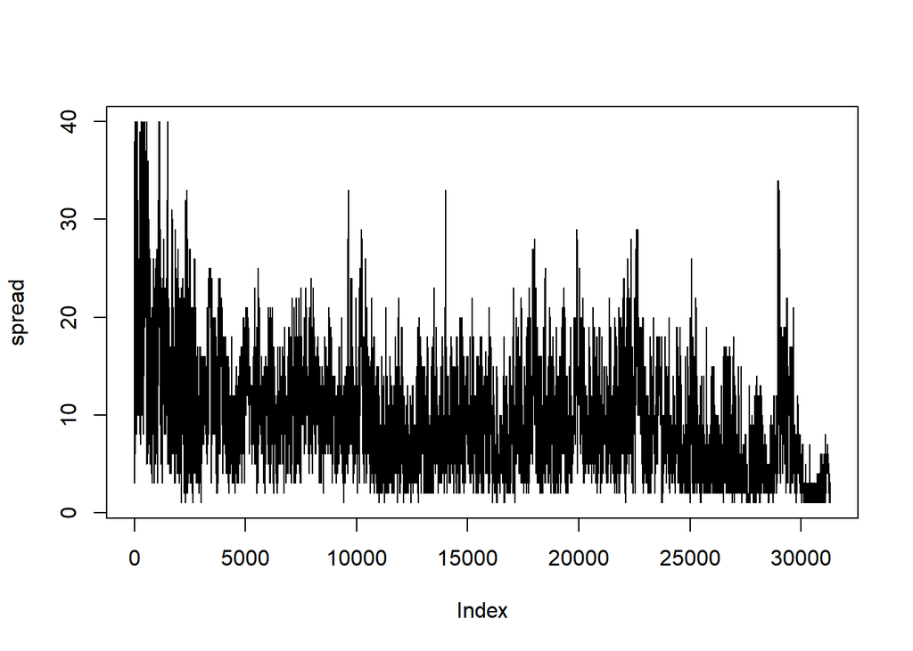

```r
spread <-data$spr*100
plot(spread,type="l")
```

```r
summary(spread)
```

```
##        V1
##  Min.   : 1.000
##  1st Qu.: 5.000
##  Median : 8.000
##  Mean   : 9.397
##  3rd Qu.:12.000
##  Max.   :40.000
```

Time for this code chunk to run: 0.871279954910278

Since the minimum spread level in the data is one tick (one dollar cent), we work on this time series minus one, i.e on $x_t = s_t-1$.

```r
library(lubridate)
library(ggplot2)
library(dplyr)


allx <- spread-1

summary(allx)
```

```
##        V1
##  Min.   : 0.000
##  1st Qu.: 4.000
##  Median : 7.000
##  Mean   : 8.397
##  3rd Qu.:11.000
##  Max.   :39.000
```

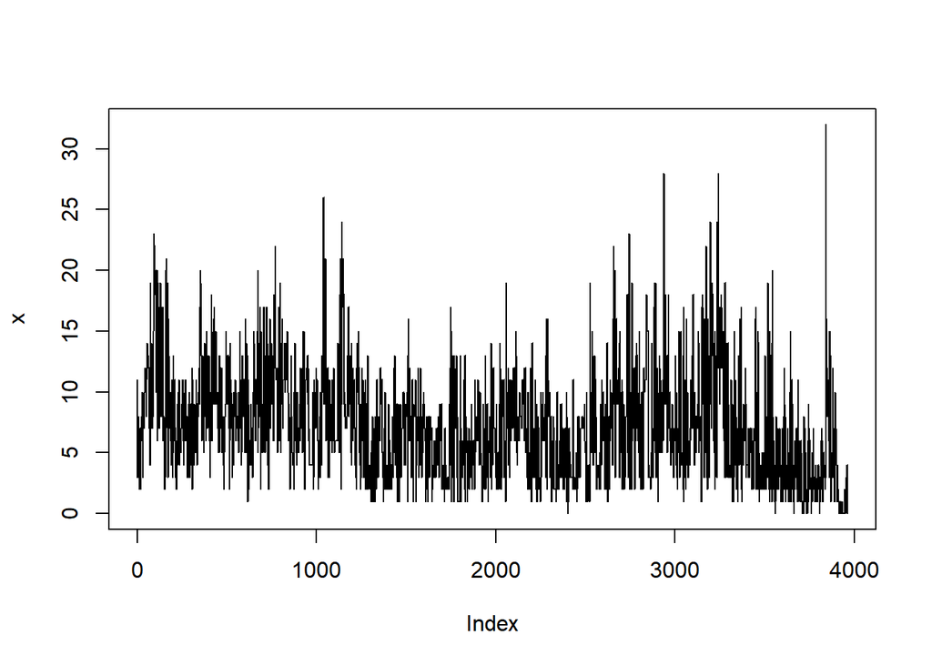

```r
x <- data$y #spread data in cent (5s sampling)
n<-length(x)
obsgrid <- 1/n

plot(x, type="l")
```

```r
summary(x)
```

```
##        V1
##  Min.   : 0.000
##  1st Qu.: 4.000
##  Median : 7.000
##  Mean   : 7.152
##  3rd Qu.:10.000
##  Max.   :32.000
```

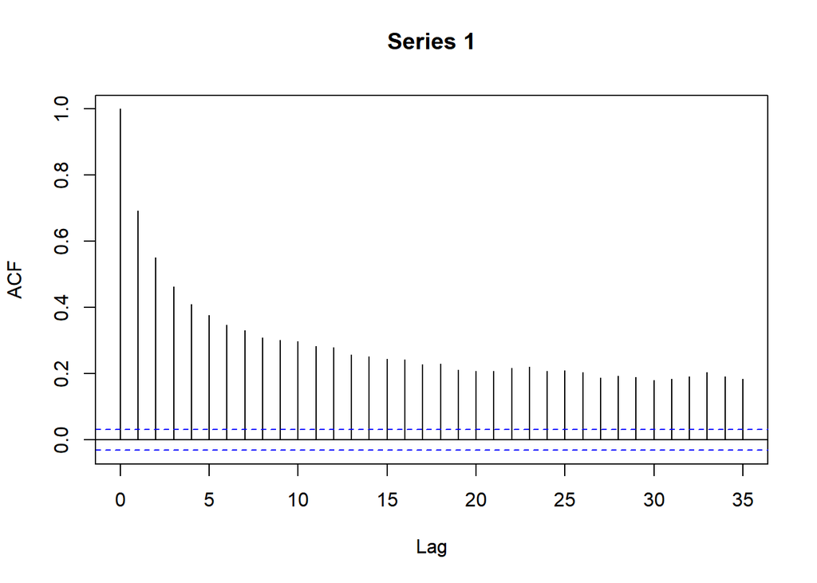

```r
acf(x)
```

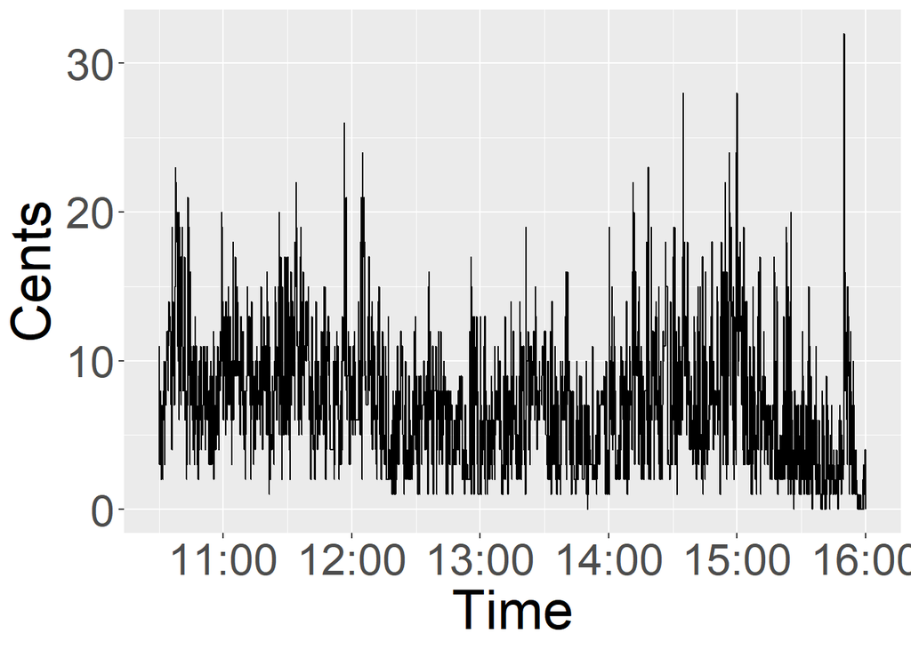

```r
#Plots using ggplot
 theme_update(text = element_text(size=30)) #Increase font size in labels
#Plot as time series with correct times
time_seq <- seq(from = lubridate::mdy_hms("04-05-2020 10:30:00"),to = lubridate::mdy_hms("04-05-2020 16:00:00"), by = "5 sec")
spread.ts <- data.frame(time=time_seq,
                        value=x)
p <- ggplot(spread.ts, aes(x=time,y=value))+
  geom_line()+
  xlab("Time")+
  ylab("Cents")
p
```

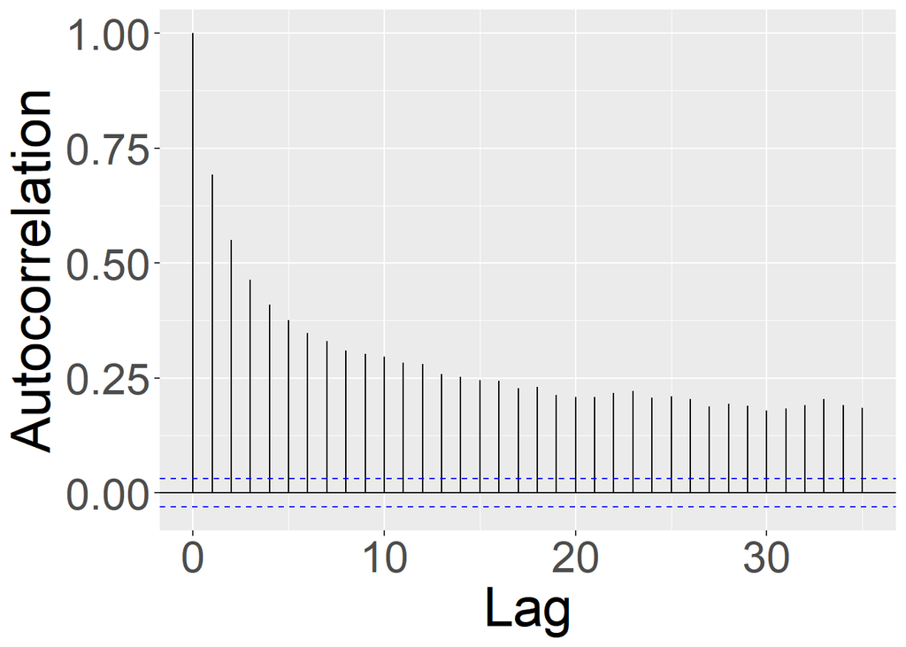

```r
ggsave("TS.eps", width = 20, height = 20, units = "cm")
#Plot the acf
my_acf <- acf(x, plot = FALSE)
my_acfdf <- with(my_acf, data.frame(lag, acf))

#Confidence limits
alpha <- 0.95
conf.lims <- c(-1,1)*qnorm((1 + alpha)/2)/sqrt(n)

q <- ggplot(data = my_acfdf, mapping = aes(x = lag, y = acf)) +
       geom_hline(aes(yintercept = 0)) +
       geom_segment(mapping = aes(xend = lag, yend = 0))+
        geom_hline(yintercept=conf.lims, lty=2, col='blue') +
        xlab("Lag")+
        ylab("Autocorrelation")
q
```

```r
ggsave("ACF.eps", width = 20, height = 20, units = "cm")
```

Time for this code chunk to run: 4.17461800575256

## Fitting the trawl function

We want to fit the trawl function not-parameterically and use the following function:

```r
#Fit trawl function
##Given a path, estimate the trawl function up to lag lags

nonpar_trawlest <- function(data, Delta, lag=100){
  a_hat <- vector(mode = "numeric", length = lag)
  cov <- acf(data, lag=lag,type = c("covariance"), plot = FALSE)$acf
  for(i in 0:lag){
    a_hat[i]<- -(cov[i+1]-cov[i])/Delta
  }
  return(a_hat)
}
```

Time for this code chunk to run: 0.00689697265625

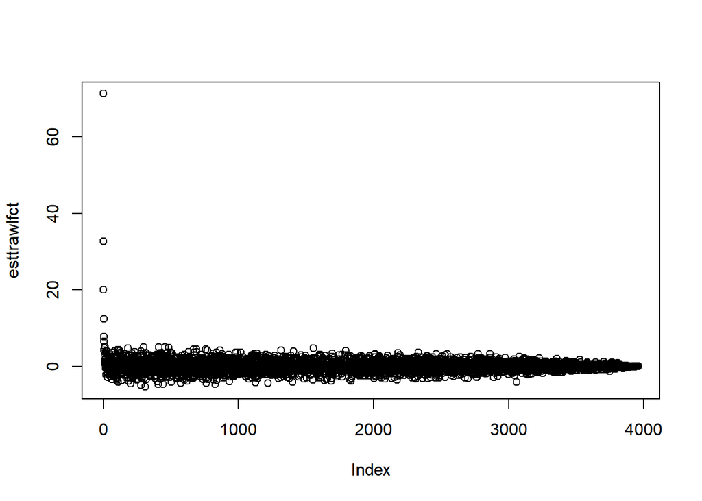

```r
library(latex2exp)

my_lag <-n-1
my_Delta <-1/12#sampling in 5s=1/12 min
esttrawlfct <- nonpar_trawlest(x, Delta=my_Delta, lag=my_lag)
plot(esttrawlfct)
```

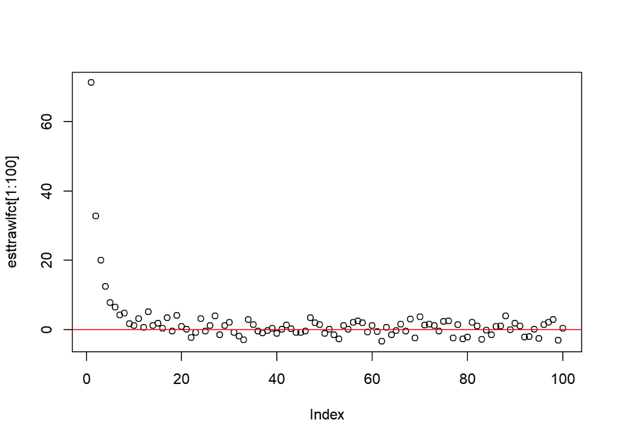

```r
plot(esttrawlfct[1:100])
abline(h=0,col="red")
```

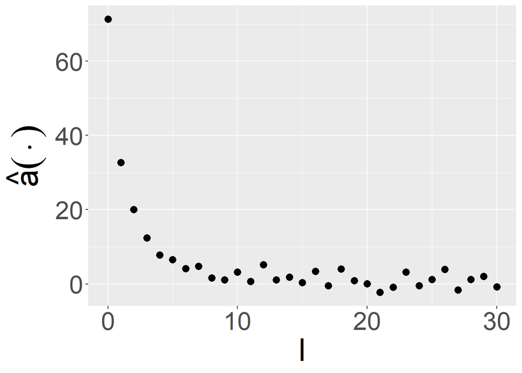

```r
#print(esttrawlfct)

#Using ggplot
l_seq <- seq(from = 0,to = (my_lag-1), by = 1)
esttrawlfct.data <- data.frame(l=l_seq[1:31],
                        value=esttrawlfct[1:31])
p2 <- ggplot(esttrawlfct.data, aes(x=l,y=value))+
  geom_point(size=3)+
  xlab("l")+
  ylab(TeX("$\\hat{a}(\\cdot)$"))
p2
```

```r
ggsave("hata.eps", width = 20, height = 20, units = "cm")
```

Time for this code chunk to run: 1.33285284042358

We note that the original estimator can become negative. We consider the modified estimator
$$\hat
a_m(t):=\max\{\hat a(t), 0\}.$$

```r
nonpar_trawlest_pos <- function(data, Delta, lag=100){
  a_hat <- vector(mode = "numeric", length = lag)
  cov <- acf(data, lag=lag,type = c("covariance"), plot = FALSE)$acf
  for(i in 1:(lag-1)){
    a_hat[i]<- max(-(cov[i+1]-cov[i])/Delta,0)
  }
  return(a_hat) #note that a_hat[1] corresponds to ^a(0) etc
}
```

Time for this code chunk to run: 0.00504302978515625

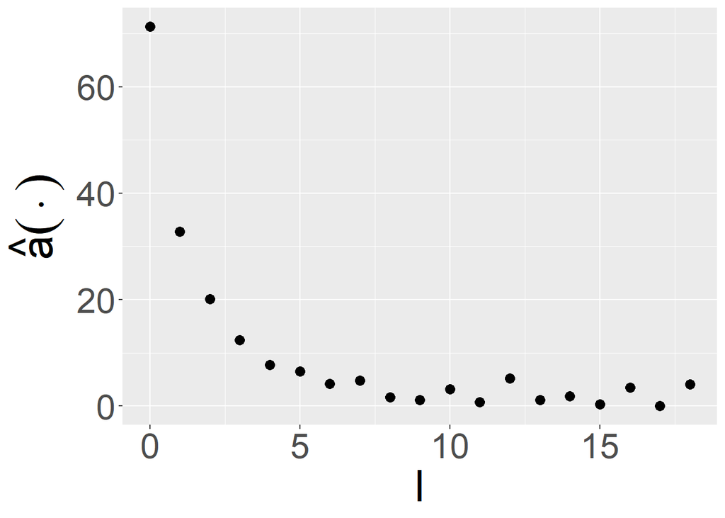

```r
esttrawlfct_pos <- nonpar_trawlest_pos(x, Delta=my_Delta, lag=my_lag)

#print(esttrawlfct_pos)

#Using ggplot
l_seq <- seq(from = 0,to = (my_lag-1), by = 1)
esttrawlfct.data <- data.frame(l=l_seq[1:19],
                        value=esttrawlfct_pos[1:19])
p3 <- ggplot(esttrawlfct.data, aes(x=l,y=value))+
  geom_point( size=3)+
  xlab("l")+
  ylab(TeX("$\\hat{a}(\\cdot)$"))
p3
```

```r
ggsave("hatapos.eps", width = 20, height = 20, units = "cm")
```

Time for this code chunk to run: 0.605833053588867

We note that, in order to avoid identifiability issues, we either need to work under the assumption that $Var(L')=1$ or that the trawl function is standardised with $Leb(A)=1$.

As in the article, we assume that $Var(L')=1$.

(If we set $Leb(A)=1$ instead, then our estimator estimates the function $t \mapsto Var(L')a(t)$.)

We note that
$$Var(L(A_t))=leb(A)Var(L')=leb(A).$$
I.e. we can use the empirical variance to estimate $leb(A)$. Alternatively, we note that we have estimates $\hat a(t\Delta)$ for $t=0,1,..lag$. So we can compute
$$\widehat{Leb(A)}\approx \sum_{t=0}^{lag}\hat a(t\Delta)\Delta.$$
Let us compare the two estimates:

```r
var(x)
```

```
##          [,1]
## [1,] 19.28245
```

```r
lebA <-sum(esttrawlfct)*my_Delta
lebA
```

```
## [1] 19.28453
```

```r
lebA_pos <-sum(esttrawlfct_pos)*my_Delta
lebA_pos
```

```
## [1] 181.554
```

Time for this code chunk to run: 0.0173330307006836

We note that the modified estimator which is guaranteed to stay positive performs poorly when estimating integrals over the estimated trawl function.

## Confidence intervals for the trawl function

We can now add confidence bounds around the estimates of the trawl function:
$$P\left(a(t)\in \left(\hat
a(t)-z_{\beta/2}\sqrt{\frac{\sigma^2_a(t)}{n\Delta_n}}, \hat
a(t)+z_{\beta/2}\sqrt{\frac{\sigma^2_a(t)}{n\Delta_n}}\right)\right)=1-\beta.$$
In order to use this in practice, we need a feasible estimate for $\sigma_a^2$. In particular, we need to estimate the fourth cumulant $c_4=\int x^4\nu(dx)$. We recall the following relation between the 4th cumulant $c_4$ and the 4th centred moment denoted by $\mu_4$:
$$c_4(L')=\int x^4 \nu(dx)=\mu_4(L')
-3(Var(L'))^2=\mu_4(L')-3.$$
We can use the empirical central moment to estimate $\mu_4(X)$ for $X_t=L(A_t)$.
$$\widehat{\mu_4}(X)=\frac{1}{nobs}\sum_{i=1}^{nobs}(x_i-\bar x)^4.$$

```r
#Estimation of Leb(A)
lebA_est <-function(avector, Delta){
  lebA <-sum(avector)*my_Delta
  return(lebA)
}


############
#Estimation of fourth cumulant c_4(L')=(mu_4(X)-3mu_2(X))/Leb(A)
library(e1071)
c4_est <-function(data, lebA){

  #Note that there is no Bessel correction in the central moments below
  mu4X <- e1071::moment(data, order = 4, center=TRUE)
  mu2X <- e1071::moment(data, order = 2, center=TRUE)
  c4X <- mu4X-3*mu2X
  c4 <-c4X/lebA
  return(c4)
}
```

Time for this code chunk to run: 0.0750269889831543

```r
my_lebA <- lebA_est(esttrawlfct, my_Delta)
c4 <-c4_est(x, my_lebA)
c4
```

```
## [1] 73.96196
```

Time for this code chunk to run: 0.0188479423522949

Now we have all the ingredients to compute the asymptotic variance.

```r
asymptotic_variance_nonpar_stepfct <- function(t, kfour, varlevyseed=1, my_delta, avector)
{
  #avector contains the estimates for a(0), a(my_delta), a(2my_delta),...,a((my_n-1)my_delta)
  avector_length <- length(avector)
  i <- floor(t/my_delta)

  if(i==0){
    v<-kfour*avector[1]
  }
  else{

  v1  <- kfour*avector[i+1]

  v2 <- 2*varlevyseed^2*sum(avector^2)*my_delta

  tmp3<-0
  for(l in 0:(min(i,avector_length-1-i))){
    tmp3<- tmp3+avector[i-l+1]*avector[i+l+1]
  }
  v3  <- 2*varlevyseed^2*tmp3*my_delta

  tmp4<-0
  for(l in i:(avector_length-1-i)){
    if(i>(avector_length-1-i)) break
    tmp4<- tmp4+avector[l-i+1]*avector[i+l+1]
  }
  v4  <- 2*varlevyseed^2*tmp4*my_delta

  v <- v1+v2+v3+v4
  }
  return(v)
}
```

Time for this code chunk to run: 0.0067448616027832

We plot the asymptotic variance on our $\Delta$-grid:

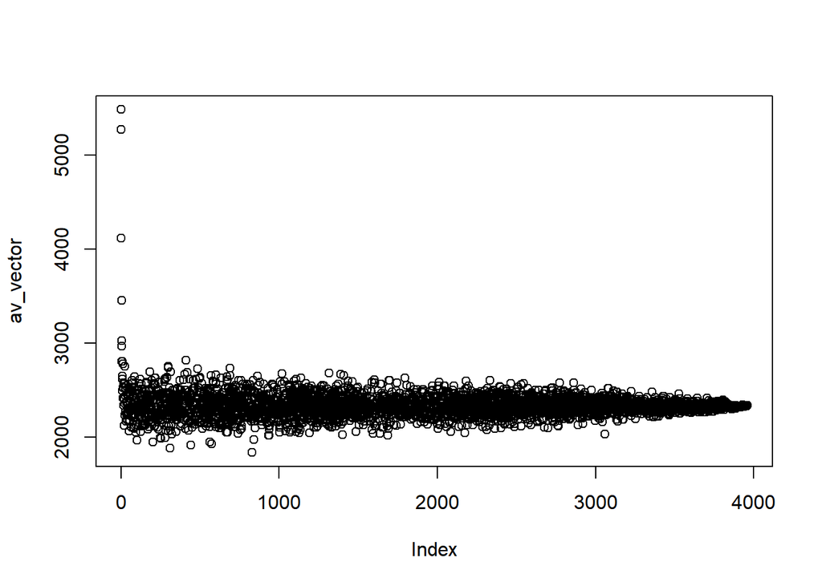

```r
av_vector <-numeric(my_lag)
for(i in 1:my_lag){
  av_vector[i] <- asymptotic_variance_nonpar_stepfct((i-1)*my_Delta, c4, varlevyseed=1, my_Delta, esttrawlfct)
  #print(i)
  #print(av_vector[i])
}
#Note that av_vector[1] contains the value for i=0 etc
plot(av_vector)
```

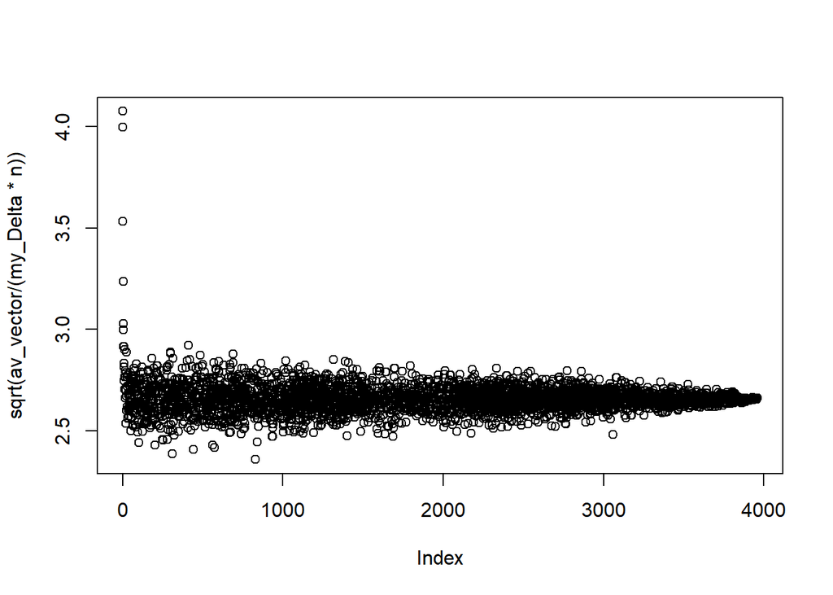

```r
plot(sqrt(av_vector/(my_Delta*n)))
```

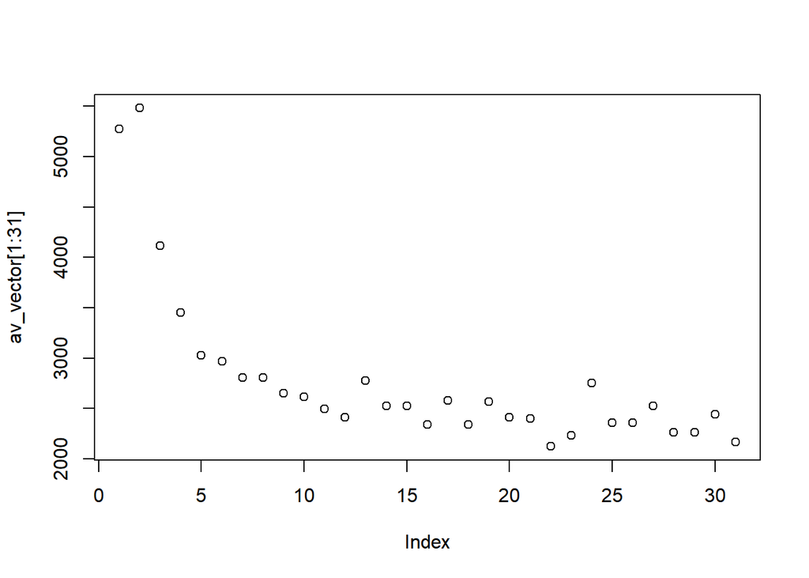

```r
plot(av_vector[1:31])
```

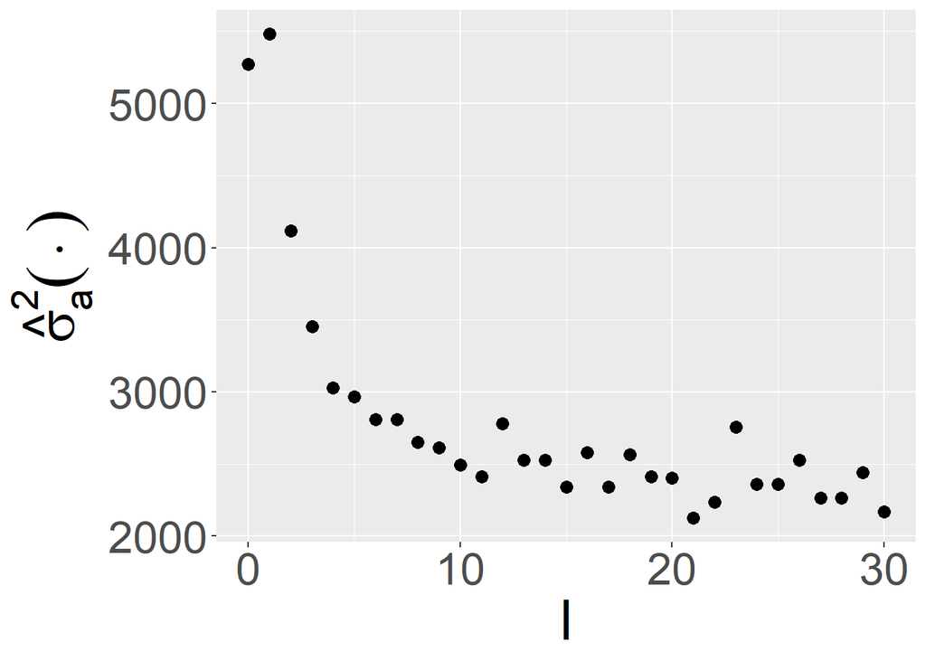

```r
#Using ggplot
l_seq <- seq(from = 0,to = (my_lag-1), by = 1)
av.data <- data.frame(l=l_seq[1:31],
                        value=av_vector[1:31])
p4 <- ggplot(av.data, aes(x=l,y=value))+
  geom_point( size=3)+
  xlab("l")+
  ylab(TeX("$\\hat{\\sigma}_a^2(\\cdot)$"))
p4
```

```r
ggsave("hatav.eps", width = 20, height = 20, units = "cm")
```

Time for this code chunk to run: 3.71387195587158